# Assignment 2

Author

Arianna Hernandez

## **Assignment 02 - Data Viz and Wrangling**

September 27, 2024

## **Due Date**

This assignment is due by 11:59pm Pacific Time, October 11th, 2024.

For this assignment, we will be analyzing data from USC’s Children’s Health Study. The learning objectives are to conduct data wrangling and visualize the data with key questions in mind.

## **Data Wrangling**

You will need to download two datasets from https://github.com/USCbiostats/data-science-data. The [individual](https://raw.githubusercontent.com/USCbiostats/data-science-data/master/01_chs/chs_individual.csv) and [regional](https://raw.githubusercontent.com/USCbiostats/data-science-data/master/01_chs/chs_regional.csv) CHS datasets in `01_chs`. The individual data includes personal and health characteristics of children in 12 communities across Southern California. The regional data include air quality measurements at the community level. Once downloaded, you can merge these datasets using the location variable. Once combined, you will need to do the following:

```r
individual <- read.csv("chs_individual.csv")
regional <- read.csv("chs_regional.csv")
mdata <- merge(individual, regional, by = "townname", all = TRUE)
```

1. After merging the data, make sure you don’t have any duplicates by counting the number of rows. Make sure it matches.

   In the case of missing values, impute data using the average amongst individuals with the same values for the “male” and “hispanic” variables. For categorical variables, take the mode. If you are interested (and feel adventurous) in the theme of Data Imputation, take a look at this paper on “Multiple Imputation” using the Amelia R package [here](https://gking.harvard.edu/files/gking/files/amelia_jss.pdf).

```r
nrow(individual)
```

```
[1] 1200
```

```r
nrow(mdata)
```

```
[1] 1200
```

```r
cdata <- mdata[!duplicated(mdata), ]
summary(cdata) ##checking which vars have NA values
```

```
   townname              sid              male            race
 Length:1200        Min.   :   1.0   Min.   :0.0000   Length:1200
 Class :character   1st Qu.: 528.8   1st Qu.:0.0000   Class :character
 Mode  :character   Median :1041.5   Median :0.0000   Mode  :character
                    Mean   :1037.5   Mean   :0.4917
                    3rd Qu.:1554.2   3rd Qu.:1.0000
                    Max.   :2053.0   Max.   :1.0000

    hispanic          agepft           height        weight
 Min.   :0.0000   Min.   : 8.961   Min.   :114   Min.   : 42.00
 1st Qu.:0.0000   1st Qu.: 9.610   1st Qu.:135   1st Qu.: 65.00
 Median :0.0000   Median : 9.906   Median :139   Median : 74.00
 Mean   :0.4342   Mean   : 9.924   Mean   :139   Mean   : 79.33
 3rd Qu.:1.0000   3rd Qu.:10.177   3rd Qu.:143   3rd Qu.: 89.00
 Max.   :1.0000   Max.   :12.731   Max.   :165   Max.   :207.00
                  NA's   :89       NA's   :89    NA's   :89
      bmi            asthma       active_asthma  father_asthma
 Min.   :11.30   Min.   :0.0000   Min.   :0.00   Min.   :0.00000
 1st Qu.:15.78   1st Qu.:0.0000   1st Qu.:0.00   1st Qu.:0.00000
 Median :17.48   Median :0.0000   Median :0.00   Median :0.00000
 Mean   :18.50   Mean   :0.1463   Mean   :0.19   Mean   :0.08318
 3rd Qu.:20.35   3rd Qu.:0.0000   3rd Qu.:0.00   3rd Qu.:0.00000
 Max.   :41.27   Max.   :1.0000   Max.   :1.00   Max.   :1.00000
 NA's   :89      NA's   :31                      NA's   :106
 mother_asthma        wheeze          hayfever         allergy
 Min.   :0.0000   Min.   :0.0000   Min.   :0.0000   Min.   :0.0000
 1st Qu.:0.0000   1st Qu.:0.0000   1st Qu.:0.0000   1st Qu.:0.0000
 Median :0.0000   Median :0.0000   Median :0.0000   Median :0.0000
 Mean   :0.1023   Mean   :0.3313   Mean   :0.1747   Mean   :0.2929
 3rd Qu.:0.0000   3rd Qu.:1.0000   3rd Qu.:0.0000   3rd Qu.:1.0000
 Max.   :1.0000   Max.   :1.0000   Max.   :1.0000   Max.   :1.0000
 NA's   :56       NA's   :71       NA's   :118      NA's   :63
  educ_parent        smoke             pets           gasstove
 Min.   :1.000   Min.   :0.0000   Min.   :0.0000   Min.   :0.0000
 1st Qu.:2.000   1st Qu.:0.0000   1st Qu.:1.0000   1st Qu.:1.0000
 Median :3.000   Median :0.0000   Median :1.0000   Median :1.0000
 Mean   :2.797   Mean   :0.1638   Mean   :0.7667   Mean   :0.7815
 3rd Qu.:3.000   3rd Qu.:0.0000   3rd Qu.:1.0000   3rd Qu.:1.0000
 Max.   :5.000   Max.   :1.0000   Max.   :1.0000   Max.   :1.0000
 NA's   :64      NA's   :40                        NA's   :33
```

[output cut: 48 more lines]

```
     iacid           oacid        total_acids          lon
 Min.   :0.760   Min.   :1.090   Min.   : 1.520   Min.   :-120.7
 1st Qu.:1.835   1st Qu.:2.978   1st Qu.: 4.930   1st Qu.:-118.8
 Median :2.825   Median :4.135   Median : 6.370   Median :-117.7
 Mean   :2.788   Mean   :4.342   Mean   : 6.708   Mean   :-118.3
 3rd Qu.:3.817   3rd Qu.:5.982   3rd Qu.: 9.395   3rd Qu.:-117.4
 Max.   :4.620   Max.   :7.400   Max.   :11.430   Max.   :-116.8

      lat
 Min.   :32.84
 1st Qu.:33.93
 Median :34.10
 Mean   :34.20
 3rd Qu.:34.65
 Max.   :35.49
```

```r
str(cdata)
```

```
'data.frame':   1200 obs. of  49 variables:
 $ townname     : chr  "Alpine" "Alpine" "Alpine" "Alpine" ...
 $ sid          : int  841 835 838 840 865 867 842 839 844 847 ...
 $ male         : int  1 0 0 0 0 0 1 0 1 1 ...
 $ race         : chr  "W" "W" "O" "W" ...
 $ hispanic     : int  1 0 1 0 0 1 1 1 1 0 ...
 $ agepft       : num  10.55 10.1 9.49 9.97 10.04 ...
 $ height       : int  150 143 133 146 162 141 139 142 143 137 ...
 $ weight       : int  78 69 62 78 140 94 65 86 65 69 ...
 $ bmi          : num  15.8 15.3 15.9 16.6 24.2 ...
 $ asthma       : int  0 0 0 0 1 0 0 0 NA 0 ...
 $ active_asthma: int  0 0 0 0 1 0 0 0 0 0 ...
 $ father_asthma: int  0 0 0 0 0 NA 0 0 NA 0 ...
 $ mother_asthma: int  0 0 0 0 0 0 0 1 NA 0 ...
 $ wheeze       : int  0 0 0 0 1 0 1 1 NA 0 ...
```

[output cut: 35 more lines]

```r
catVar<- c("asthma","active_asthma","father_asthma","mother_asthma","wheeze","hayfever","allergy","educ_parent","smoke", "gasstove")
nVar<- c("agepft", "height","weight", "bmi", "fev","fvc","mmef","no_24hr","pm2_5_fr")

#imputation of mean for numerical variables
for (var in nVar) {
  cdata[[var]] <- ave(
    cdata[[var]],
    cdata$male,
    cdata$hispanic,
    FUN = function(x) ifelse(is.na(x), mean(x, na.rm = TRUE), x)
  )
}

#defining mode function
mode <- function(x) {
  un <- unique(x)
  un[which.max(tabulate(match(x, un)))]
}
#finding mode for categorical variables
for(var in catVar){
  cdata[[var]]<- ave(
    cdata[[var]],
    cdata$male,
    cdata$hispanic,
    FUN = function(x) ifelse(is.na(x), mode(x),x)
  )
}
summary(cdata)
```

```
   townname              sid              male            race
 Length:1200        Min.   :   1.0   Min.   :0.0000   Length:1200
 Class :character   1st Qu.: 528.8   1st Qu.:0.0000   Class :character
 Mode  :character   Median :1041.5   Median :0.0000   Mode  :character
                    Mean   :1037.5   Mean   :0.4917
                    3rd Qu.:1554.2   3rd Qu.:1.0000
                    Max.   :2053.0   Max.   :1.0000
    hispanic          agepft           height        weight
 Min.   :0.0000   Min.   : 8.961   Min.   :114   Min.   : 42.00
 1st Qu.:0.0000   1st Qu.: 9.632   1st Qu.:135   1st Qu.: 66.00
 Median :0.0000   Median : 9.907   Median :139   Median : 76.00
 Mean   :0.4342   Mean   : 9.923   Mean   :139   Mean   : 79.31
 3rd Qu.:1.0000   3rd Qu.:10.155   3rd Qu.:143   3rd Qu.: 87.00
 Max.   :1.0000   Max.   :12.731   Max.   :165   Max.   :207.00
      bmi            asthma       active_asthma  father_asthma
 Min.   :11.30   Min.   :0.0000   Min.   :0.00   Min.   :0.00000
 1st Qu.:15.96   1st Qu.:0.0000   1st Qu.:0.00   1st Qu.:0.00000
 Median :17.81   Median :0.0000   Median :0.00   Median :0.00000
 Mean   :18.50   Mean   :0.1425   Mean   :0.19   Mean   :0.07583
 3rd Qu.:19.99   3rd Qu.:0.0000   3rd Qu.:0.00   3rd Qu.:0.00000
 Max.   :41.27   Max.   :1.0000   Max.   :1.00   Max.   :1.00000
 mother_asthma        wheeze          hayfever         allergy
 Min.   :0.0000   Min.   :0.0000   Min.   :0.0000   Min.   :0.0000
 1st Qu.:0.0000   1st Qu.:0.0000   1st Qu.:0.0000   1st Qu.:0.0000
 Median :0.0000   Median :0.0000   Median :0.0000   Median :0.0000
 Mean   :0.0975   Mean   :0.3117   Mean   :0.1575   Mean   :0.2775
 3rd Qu.:0.0000   3rd Qu.:1.0000   3rd Qu.:0.0000   3rd Qu.:1.0000
 Max.   :1.0000   Max.   :1.0000   Max.   :1.0000   Max.   :1.0000
  educ_parent        smoke             pets           gasstove
 Min.   :1.000   Min.   :0.0000   Min.   :0.0000   Min.   :0.0000
 1st Qu.:2.000   1st Qu.:0.0000   1st Qu.:1.0000   1st Qu.:1.0000
 Median :3.000   Median :0.0000   Median :1.0000   Median :1.0000
 Mean   :2.808   Mean   :0.1583   Mean   :0.7667   Mean   :0.7875
 3rd Qu.:3.000   3rd Qu.:0.0000   3rd Qu.:1.0000   3rd Qu.:1.0000
 Max.   :5.000   Max.   :1.0000   Max.   :1.0000   Max.   :1.0000
      fev              fvc            mmef          pm25_mass
 Min.   : 984.8   Min.   : 895   Min.   : 757.6   Min.   : 5.960
 1st Qu.:1827.6   1st Qu.:2065   1st Qu.:2043.7   1st Qu.: 7.615
 Median :2016.4   Median :2282   Median :2392.1   Median :10.545
 Mean   :2030.1   Mean   :2322   Mean   :2398.6   Mean   :14.362
```

[output cut: 36 more lines]

```
 Max.   :37.97   Max.   :70.39   Max.   :42.950   Max.   :31.55
     iacid           oacid        total_acids          lon
 Min.   :0.760   Min.   :1.090   Min.   : 1.520   Min.   :-120.7
 1st Qu.:1.835   1st Qu.:2.978   1st Qu.: 4.930   1st Qu.:-118.8
 Median :2.825   Median :4.135   Median : 6.370   Median :-117.7
 Mean   :2.788   Mean   :4.342   Mean   : 6.708   Mean   :-118.3
 3rd Qu.:3.817   3rd Qu.:5.982   3rd Qu.: 9.395   3rd Qu.:-117.4
 Max.   :4.620   Max.   :7.400   Max.   :11.430   Max.   :-116.8
      lat
 Min.   :32.84
 1st Qu.:33.93
 Median :34.10
 Mean   :34.20
 3rd Qu.:34.65
 Max.   :35.49
```

2. Create a new categorical variable named “obesity_level” using the BMI measurement (underweight BMI<14; normal BMI 14-22; overweight BMI 22-24; obese BMI>24). To make sure the variable is rightly coded, create a summary table that contains the minimum BMI, maximum BMI, and the total number of observations per category.

```r
cdata<- cdata %>%
mutate(obesity_level = if_else(
  bmi< 14,"underweight BMI",if_else(
    bmi>=14 & bmi< 22,"normal BMI", if_else(
      bmi>= 22 & bmi < 24,"overweight BMI", "obese BMI"))))

cdata$obesity_level <- factor(cdata$obesity_level, levels = c("underweight BMI", "normal BMI", "overweight BMI", "obese BMI"))

#summary table
summary<- cdata %>%
  group_by(obesity_level) %>%
  summarise(
    minBMI= min(bmi),
    maxbMI = max(bmi),
    total = n()
  )

print(summary)
```

```
# A tibble: 4 × 4
  obesity_level   minBMI maxbMI total
  <fct>            <dbl>  <dbl> <int>
1 underweight BMI   11.3   14.0    35
2 normal BMI        14.0   22.0   975
3 overweight BMI    22.0   24.0    87
4 obese BMI         24.0   41.3   103
```

3. Create another categorical variable named “smoke_gas_exposure” that summarizes “Second Hand Smoke” and “Gas Stove.” The variable should have four categories in total.

```r
cdata<- cdata %>%
mutate(smoke_gas_exposure = if_else(
  smoke == 0 & gasstove == 0, "No Exposure", if_else(
    smoke == 1 & gasstove == 0, "Second-hand Smoke Exposure", if_else(
      smoke == 0 & gasstove == 1, "Gas Exposure", "Both Smoke and Gas Exposures")
    )
  )
)
cdata$smoke_gas_exposure <- factor(cdata$smoke_gas_exposure, levels = c("No Exposure", "Second-hand Smoke Exposure","Gas Exposure", "Both Smoke and Gas Exposures"))
levels(cdata$smoke_gas_exposure)
```

```
[1] "No Exposure"                  "Second-hand Smoke Exposure"
[3] "Gas Exposure"                 "Both Smoke and Gas Exposures"
```

4. Create four summary tables showing the average (or proportion, if binary) and sd of “Forced expiratory volume in 1 second (ml)” (an asthma indicator) by town, sex, obesity level, and “smoke_gas_exposure.”

```r
sum_town <- cdata %>%
  group_by(townname) %>%
  summarise(
    fev_avg = mean(fev),
    fev_sd = sd(fev)
  )
print(sum_town)
```

```
# A tibble: 12 × 3
   townname      fev_avg fev_sd
   <chr>           <dbl>  <dbl>
 1 Alpine          2087.   291.
 2 Atascadero      2076.   324.
 3 Lake Elsinore   2039.   304.
 4 Lake Gregory    2085.   320.
 5 Lancaster       2003.   317.
 6 Lompoc          2034.   351.
 7 Long Beach      1986.   319.
 8 Mira Loma       1985.   325.
 9 Riverside       1990.   278.
10 San Dimas       2027.   319.
11 Santa Maria     2026.   312.
12 Upland          2024.   343.
```

```r
sum_sex <- cdata %>%
  group_by(male) %>%
  summarise(
    fev_avg = mean(fev),
    fev_sd = sd(fev)
  )
print(sum_sex)
```

```
# A tibble: 2 × 3
   male fev_avg fev_sd
  <int>   <dbl>  <dbl>
1     0   1959.   312.
2     1   2104.   308.
```

```r
sum_ol <- cdata %>%
  group_by(obesity_level) %>%
  summarise(
    fev_avg = mean(fev),
    fev_sd = sd(fev)
  )
print(sum_ol)
```

```
# A tibble: 4 × 3
  obesity_level   fev_avg fev_sd
  <fct>             <dbl>  <dbl>
1 underweight BMI   1698.   303.
2 normal BMI        2000.   295.
3 overweight BMI    2224.   317.
4 obese BMI         2266.   325.
```

```r
sum_sge <- cdata %>%
  group_by(smoke_gas_exposure) %>%
  summarise(
    fev_avg = mean(fev),
    fev_sd = sd(fev)
  )
print(sum_sge)
```

```
# A tibble: 4 × 3
  smoke_gas_exposure           fev_avg fev_sd
  <fct>                          <dbl>  <dbl>
1 No Exposure                    2057.   329.
2 Second-hand Smoke Exposure     2056.   296.
3 Gas Exposure                   2023.   319.
4 Both Smoke and Gas Exposures   2025.   301.
```

## **Looking at the Data (EDA)**

The primary questions of interest are:

1. What is the association between BMI and FEV (forced expiratory volume)?

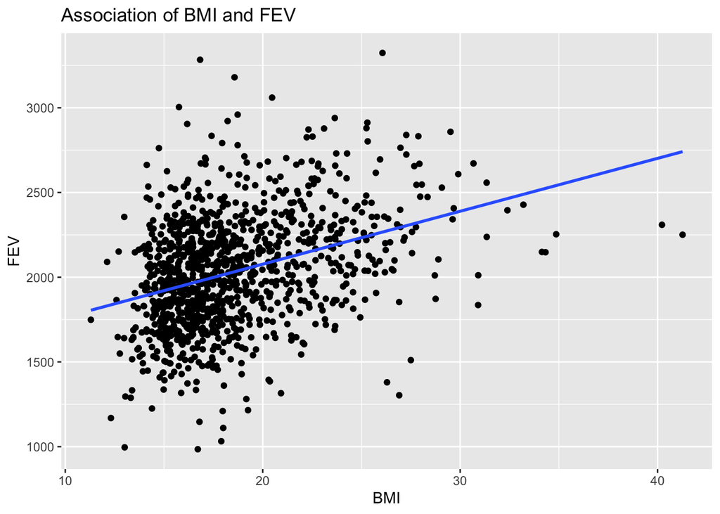

```r
ggplot(data = cdata, mapping = aes(x = bmi, y = fev)) +
  geom_point() +
  geom_smooth(method = "lm", se = FALSE)+
  labs(title = "Association of BMI and FEV", x = "BMI", y ="FEV")
```

```r
summary(lm(fev~bmi, data = cdata))
```

```
Call:
lm(formula = fev ~ bmi, data = cdata)

Residuals:
    Min      1Q  Median      3Q     Max
-989.47 -193.88  -11.32  179.43 1305.46

Coefficients:
            Estimate Std. Error t value Pr(>|t|)
(Intercept)  1452.46      44.49   32.65   <2e-16 ***
bmi            31.23       2.36   13.23   <2e-16 ***
---
Signif. codes:  0 '***' 0.001 '**' 0.01 '*' 0.05 '.' 0.1 ' ' 1

Residual standard error: 297.2 on 1198 degrees of freedom
Multiple R-squared:  0.1275,    Adjusted R-squared:  0.1268
F-statistic: 175.1 on 1 and 1198 DF,  p-value: < 2.2e-16
```

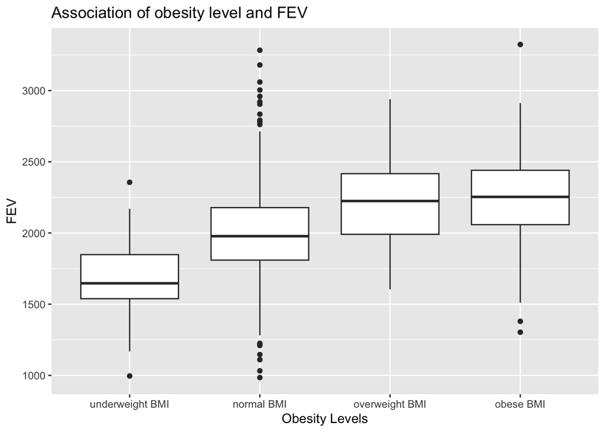

```r
ggplot(data = cdata, mapping = aes(x = obesity_level, y = fev)) +
  geom_boxplot() +
  labs(title = "Association of obesity level and FEV", x = "Obesity Levels", y ="FEV")
```

```r
summary(lm(fev~obesity_level, data = cdata))
```

```
Call:
lm(formula = fev ~ obesity_level, data = cdata)

Residuals:
     Min       1Q   Median       3Q      Max
-1014.95  -191.55   -19.47   178.41  1283.58

Coefficients:
                            Estimate Std. Error t value Pr(>|t|)
(Intercept)                  1698.33      50.67  33.517  < 2e-16 ***
obesity_levelnormal BMI       301.47      51.57   5.846 6.51e-09 ***
obesity_leveloverweight BMI   525.99      60.00   8.766  < 2e-16 ***
obesity_levelobese BMI        567.83      58.65   9.681  < 2e-16 ***
---
Signif. codes:  0 '***' 0.001 '**' 0.01 '*' 0.05 '.' 0.1 ' ' 1

Residual standard error: 299.8 on 1196 degrees of freedom
Multiple R-squared:  0.1136,    Adjusted R-squared:  0.1113
F-statistic: 51.08 on 3 and 1196 DF,  p-value: < 2.2e-16
```

Looking at the scatter plot and linear model between BMI score and FEV, we can see that there is a positive relationship between the two. At the intercept, we can see that the FEV score is assumed to be at 1452.46 and goes up 31.23ml with every unit increase of BMI, and with a p < 0.001, we can assume this difference is significant.

Further looking into the different obesity levels and their effects on FEV, we can also see this overall increase in the boxplots. A regression model on the different levels shows that BMI is significantly related to FEV in all the categories. However, the R squared indicates that only about 11.36% of the variance in the data can be explained by the model, so though there is a significant relationship, we can assume BMI is not a strong predictor of FEV.

2. What is the association between smoke and gas exposure and FEV?

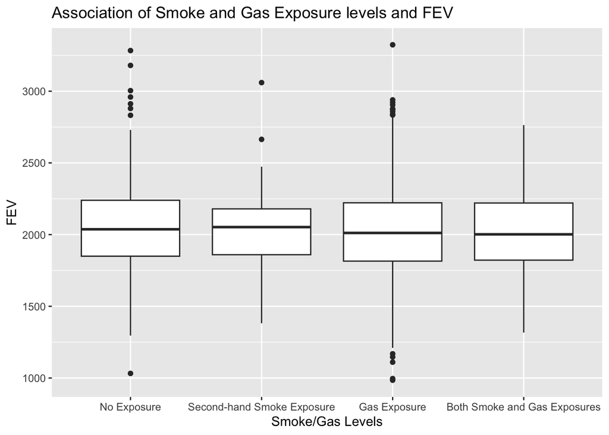

```r
ggplot(data = cdata, mapping = aes(x = smoke_gas_exposure, y = fev)) +
  geom_boxplot() +
  labs(title = "Association of Smoke and Gas Exposure levels and FEV", x = "Smoke/Gas Levels", y ="FEV")
```

```r
summary(lm(fev~smoke_gas_exposure, data = cdata))
```

```
Call:
lm(formula = fev ~ smoke_gas_exposure, data = cdata)

Residuals:
    Min      1Q  Median      3Q     Max
-1037.8  -205.3   -12.0   190.7  1301.0

Coefficients:
                                                Estimate Std. Error t value
(Intercept)                                    2056.6934    21.4950  95.682
smoke_gas_exposureSecond-hand Smoke Exposure     -0.9794    57.2079  -0.017
smoke_gas_exposureGas Exposure                  -34.0226    24.2890  -1.401
smoke_gas_exposureBoth Smoke and Gas Exposures  -31.9152    33.4527  -0.954
                                               Pr(>|t|)
(Intercept)                                      <2e-16 ***
smoke_gas_exposureSecond-hand Smoke Exposure      0.986
smoke_gas_exposureGas Exposure                    0.162
smoke_gas_exposureBoth Smoke and Gas Exposures    0.340
---
Signif. codes:  0 '***' 0.001 '**' 0.01 '*' 0.05 '.' 0.1 ' ' 1

Residual standard error: 318.1 on 1196 degrees of freedom
Multiple R-squared:  0.001868,  Adjusted R-squared:  -0.0006354
F-statistic: 0.7462 on 3 and 1196 DF,  p-value: 0.5246
```

The boxplot shows very similar levels of FEV for each different smoke/gas exposure level. Looking at the regression model, the only significant relationship is FEV and no gas/smoke exposure, though the overall p score (0.52) and r squared of 0.002 indicates no overall significance.

3. What is the association between PM2.5 exposure and FEV?

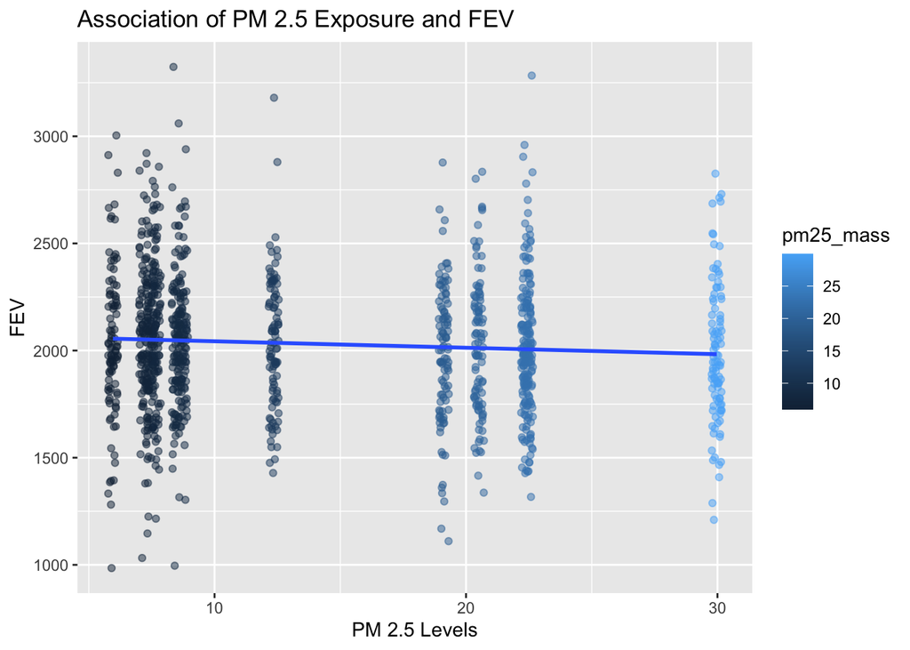

```r
ggplot(data = cdata, mapping = aes(x = pm25_mass , y = fev)) +
  geom_jitter(aes(color = pm25_mass), width = 0.2, alpha = 0.5) +
  geom_smooth(method = "lm", se = FALSE)+
  labs(title = "Association of PM 2.5 Exposure and FEV", x = "PM 2.5 Levels", y ="FEV")
```

```r
summary(lm(fev~pm25_mass, data = cdata))
```

```
Call:
lm(formula = fev ~ pm25_mass, data = cdata)

Residuals:
     Min       1Q   Median       3Q      Max
-1070.63  -206.57   -13.33   195.87  1277.65

Coefficients:
            Estimate Std. Error t value Pr(>|t|)
(Intercept) 2073.452     19.309 107.383   <2e-16 ***
pm25_mass     -3.016      1.184  -2.548    0.011 *
---
Signif. codes:  0 '***' 0.001 '**' 0.01 '*' 0.05 '.' 0.1 ' ' 1

Residual standard error: 317.3 on 1198 degrees of freedom
Multiple R-squared:  0.005389,  Adjusted R-squared:  0.004559
F-statistic: 6.492 on 1 and 1198 DF,  p-value: 0.01096
```

```r
summary(lm(fev~pm25_so4 + pm25_no3 + pm25_nh4 + pm25_oc + pm25_ec + pm25_om, data = cdata))
```

```
Call:
lm(formula = fev ~ pm25_so4 + pm25_no3 + pm25_nh4 + pm25_oc +
    pm25_ec + pm25_om, data = cdata)

Residuals:
     Min       1Q   Median       3Q      Max
-1065.76  -203.96   -12.83   194.51  1281.93

Coefficients:
            Estimate Std. Error t value Pr(>|t|)
(Intercept)  2062.51      43.07  47.883   <2e-16 ***
pm25_so4      -69.92      63.28  -1.105    0.269
pm25_no3     -122.12      77.48  -1.576    0.115
pm25_nh4      396.31     253.52   1.563    0.118
pm25_oc      -529.18    3118.38  -0.170    0.865
pm25_ec       -64.87     101.40  -0.640    0.522
pm25_om       440.24    2600.44   0.169    0.866
---
Signif. codes:  0 '***' 0.001 '**' 0.01 '*' 0.05 '.' 0.1 ' ' 1

Residual standard error: 317.6 on 1193 degrees of freedom
Multiple R-squared:  0.007691,  Adjusted R-squared:  0.002701
F-statistic: 1.541 on 6 and 1193 DF,  p-value: 0.1612
```

In this graph we can see that there is a slight negative relationship between PM 2.5 levels and FEV score, with the estimated intercept being at 2073 and decreasing 3.016 with each unit increase of PM 2.5. The P = 0.01 so we can assume significance, however R squared of 0.005 indicates it is not a strong predictor of FEV. I also looked at the relationship between the components and overall FEV effect and found no significant difference.

Follow the EDA checklist from week 3 and the previous assignment. Be sure to focus on the key variables.

## **Visualization**

Create the following figures and interpret them. Be sure to include easily understandable axes, titles, and legends.

1. Facet plot showing scatterplots with regression lines of BMI vs FEV by “townname”.

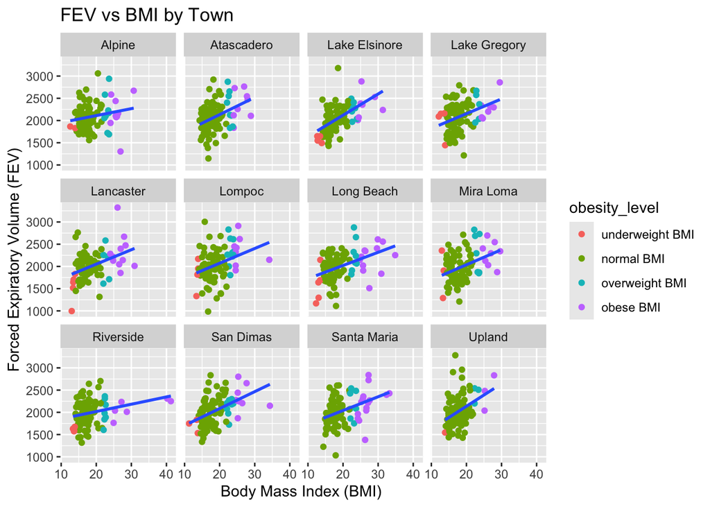

```r
ggplot(data = cdata, aes(x = bmi, y = fev)) +
  geom_point(aes(color = obesity_level)) +
  geom_smooth(method = "lm", se = FALSE) +
  facet_wrap(~ townname) +
  labs(title = "FEV vs BMI by Town",
       x = "Body Mass Index (BMI) ",
       y = "Forced Expiratory Volume (FEV)")
```

All the towns seem to have a somewhat similar-positive relationship between BMI and FEV score. However, Atascadero, Lake Elsinore, and Upland seem to have the strongest relationship. Riverside’s regression seems like it might be affected by the plotted points around 40, which seem to be outliers.

2. Stacked histograms of FEV by BMI category and FEV by smoke/gas exposure. Use different color schemes than the ggplot default.

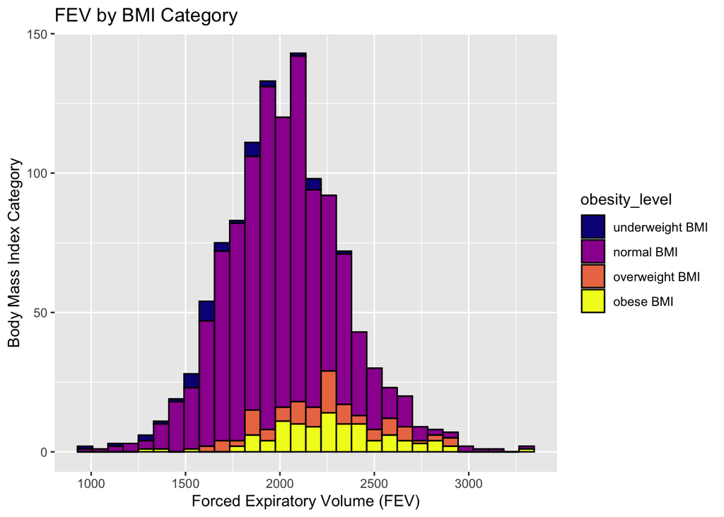

```r
cdata %>%
  ggplot(aes(x = fev, fill = obesity_level)) +
  geom_histogram(position = "stack", color = "black") +
  scale_fill_viridis_d(option = "C") +
  labs(title = "FEV by BMI Category",
       x ="Forced Expiratory Volume (FEV)",
       y = "Body Mass Index Category")
```

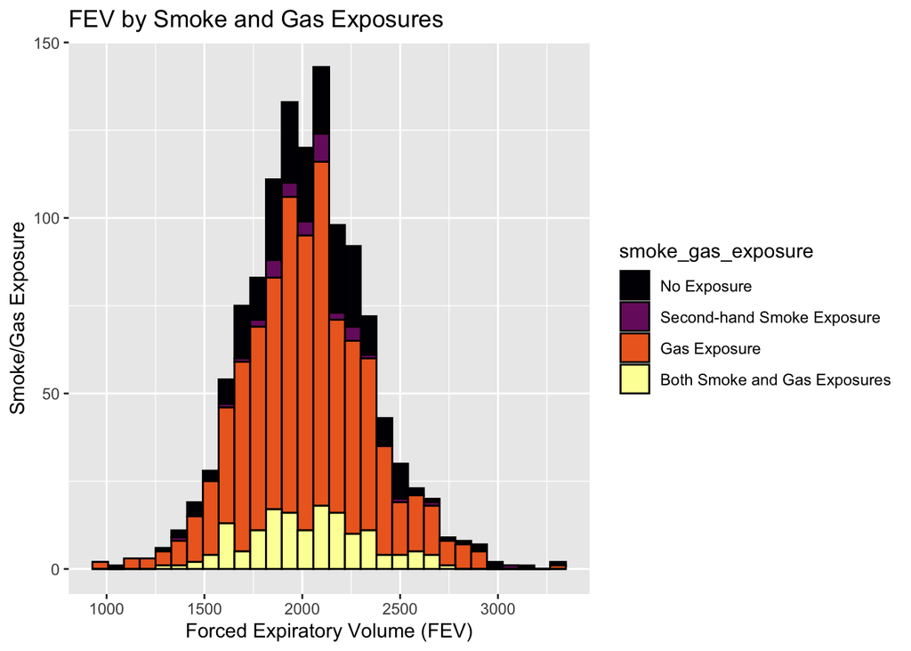

```r
cdata %>%
  ggplot(aes(x = fev, fill = smoke_gas_exposure)) +
  geom_histogram(position = "stack", color = "black") +
  scale_fill_viridis_d(option = "B") +
  labs(title = "FEV by Smoke and Gas Exposures",
       x ="Forced Expiratory Volume (FEV)",
       y = "Smoke/Gas Exposure")
```

The FEV by BMI category shows a normal-ish distribution of FEV scores for all the BMI categories, with the overweight and obese categories showing a longer right tail and therefore higher FEV, while the underweight category seems to have a longer left tail, indicating lower FEV Values. This graph shows the same trend we saw earlier, where higher BMI scores increase FEV slightly.

3. Barchart of BMI by smoke/gas exposure.

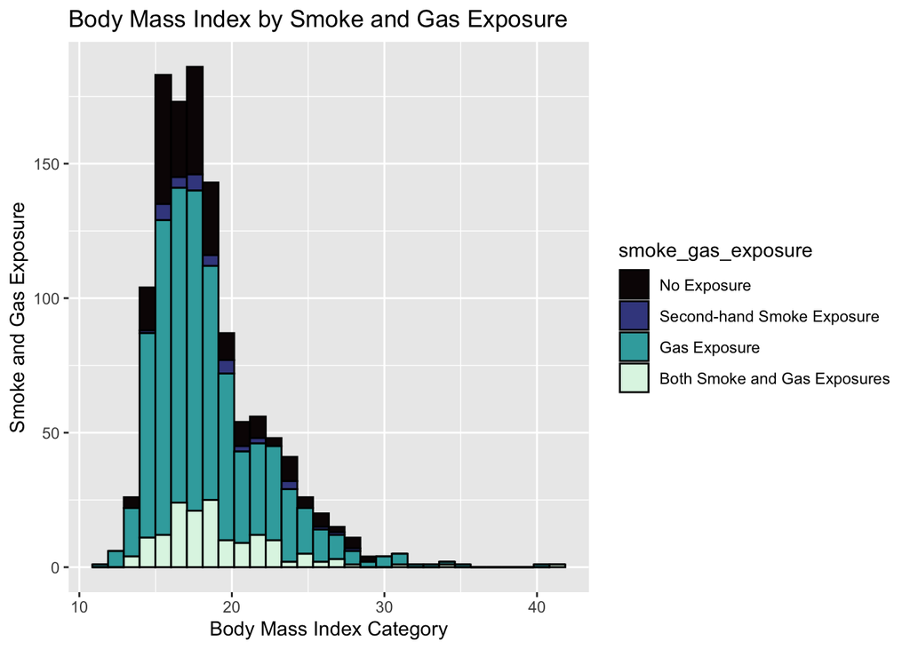

```r
cdata %>%
  ggplot(aes(x =bmi, fill = smoke_gas_exposure)) +
  geom_histogram(color = "black") +
  scale_fill_viridis_d(option = "G") +
  labs(title = "Body Mass Index by Smoke and Gas Exposure ",
       x ="Body Mass Index Category",
       y = "Smoke and Gas Exposure")
```

Here, we can see that kids with no exposure fell mainly within the range of a “normal” BMI, with some in the “overweight” and “obese” categories. The lowest BMI was seen for children with gas stoves in their home, while the highest BMI’s were seen for kids with both Gas exposure and second-hand smoke, as well as just gas exposures. This graph indicates that there is a possible relationship between gas/smoke exposure and unhealthy body weight in the children of this study.

4. Statistical summary graphs of FEV by BMI and FEV by smoke/gas exposure category.

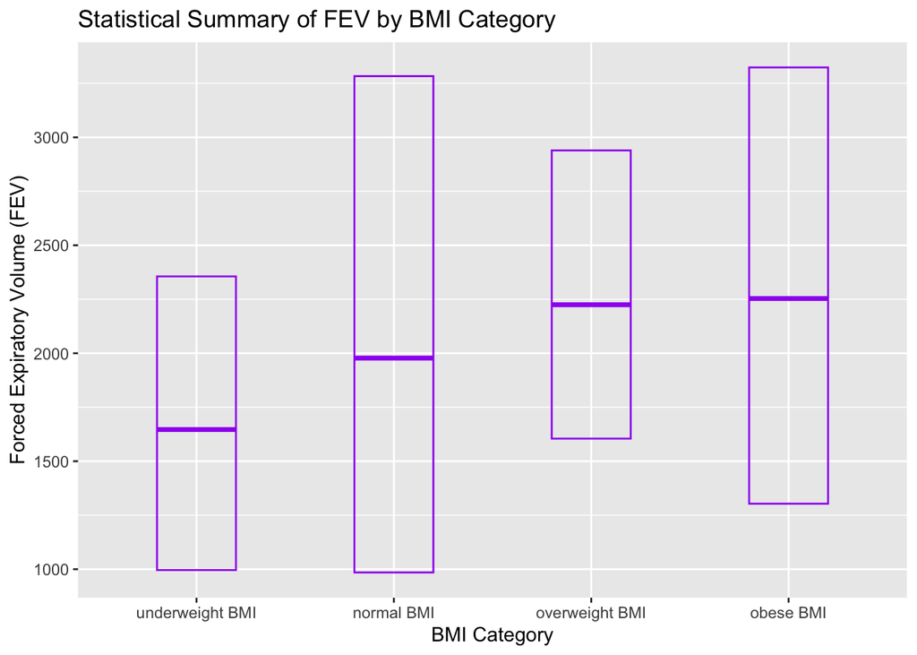

```r
cdata %>%
  ggplot(aes(x = obesity_level, y = fev)) +
    stat_summary(fun.min = min, fun.max = max, fun = median, geom = "crossbar", width = 0.4, color = "purple") +
    labs(title = "Statistical Summary of FEV by BMI Category",
         x = "BMI Category",
         y = "Forced Expiratory Volume (FEV)")
```

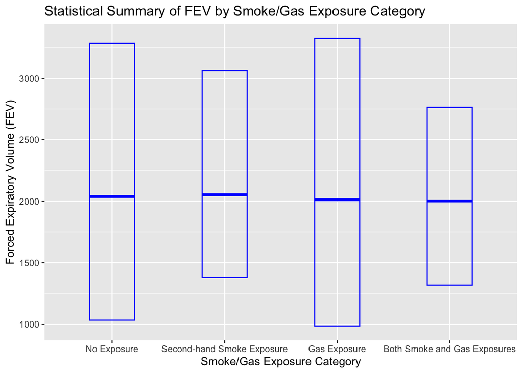

```r
cdata %>%
  ggplot(aes(x = smoke_gas_exposure, y = fev)) +
    stat_summary(fun.min = min, fun.max = max, fun = median, geom = "crossbar", width = 0.4, color = 'blue') +
    labs(title = "Statistical Summary of FEV by Smoke/Gas Exposure Category",
         x = "Smoke/Gas Exposure Category",
         y = "Forced Expiratory Volume (FEV)")
```

Here, we can see that the children within the “underweight” BMI category had the lowest median FEV, while children within the “overweight” and “obese” categories had the highest median FEV scores. Though kids within the “normal” BMI category had the highest variance in FEV, their median sits in between all the other categories–indicating a relationship between FEV and BMI.

Additionally, the smoke/ gas graph shows that the medians between all four categories are somewhat the same. Second-hand smoke exposure is slightly higher than all the others, but not by any significant amount. However, as we had seen previously, we can see the highest variance in values in both the “no exposure” category, as well as the “gas exposure” category. From this graph it is worth further investigating the effects of gas exposure and FEV values.

5. A leaflet map showing the concentrations of PM2.5 mass in each of the CHS communities.

```r
mass.pal <- colorNumeric(c('goldenrod','darkorange','brown'), domain=cdata$pm25_mass)


leaflet(cdata) %>%
  addProviderTiles('CartoDB.Positron') %>%
  addCircles(
    lat = ~lat,
    lng= ~lon,
    radius = ~pm25_mass*300,  # Adjust radius based on PM2.5 concentration
    color = ~ mass.pal(pm25_mass),      # Color of the circles
    stroke = FALSE,
    fillOpacity = 0.5,
    popup = ~paste(townname, "<br>", "PM2.5 Mass:", pm25_mass, "µg/m³")  # Popup text
  ) %>%
  addLegend('bottomleft', pal=mass.pal, values=cdata$pm25_mass,
          title='PM 2.5 Mass, µg/m³ ', opacity=1)
```

[interactive chart not shown]

Highest concentration of PM 2.5 mass is seen in Mira Loma, at 29.97 µg/m³, while Lompoc seems to have the lowest concentration at 5.96 µg/m³. Graph indicates highest PM 2.5 levels can be found nearest to Los Angeles, while the most northern/southern areas seem to have the lowest PM 2.5 Concentrations.

6. Choose a visualization to examine whether PM2.5 mass is associated with FEV.

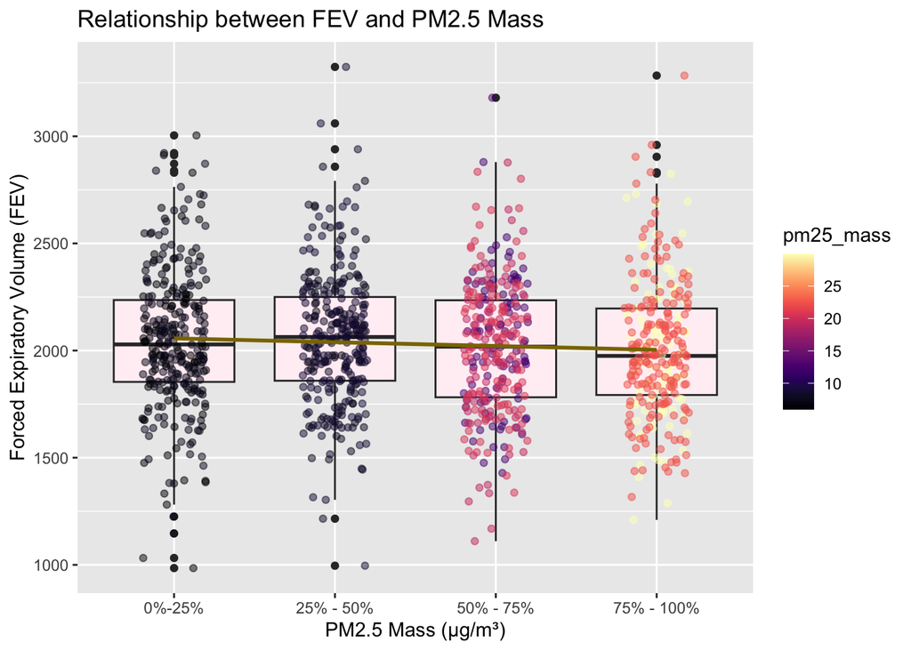

```r
cdata<- cdata %>%
  mutate(pm25_cat = cut(pm25_mass, breaks = quantile(pm25_mass),
                        labels = c("0%-25%", "25% - 50%", "50% - 75%", "75% - 100%"),
                        include.lowest = TRUE))

ggplot(cdata, aes(x = pm25_cat, y = fev)) +
  geom_boxplot(fill = "lavenderblush") +
  geom_jitter(aes(color = pm25_mass), width = 0.2, alpha = 0.5) +
  geom_smooth(method = "lm", aes(group = 1), color = "gold4", se = FALSE) +
  scale_color_viridis(option = "A") +
  labs(title = "Relationship between FEV and PM2.5 Mass",
       x = "PM2.5 Mass (µg/m³)",
       y = "Forced Expiratory Volume (FEV)")
```

As seen in the previous scatter plot, there seems to be a slightly negative relationship between FEV and PM 2.5 mass, however it doesn’t seem very significant. Variance seems about the same for all the categories, and the medians vary slightly, but not enough to cause concern. From this graph, I would conclude there is no relationship between the two.